# DSCI353-353m-453: Class 02a-p Open Data Science Tool Chain

Profs: R. H. French, L. S. Bruckman, P. Leu, K. Davis, S. Cirlos

TAs: W. Oltjen, K. Hernandez, M. Li, M. Li, D. Colvin

24 January, 2023

#### Class Readings, Assignments, Textbooks Syllabus Topics

##### Syllabus

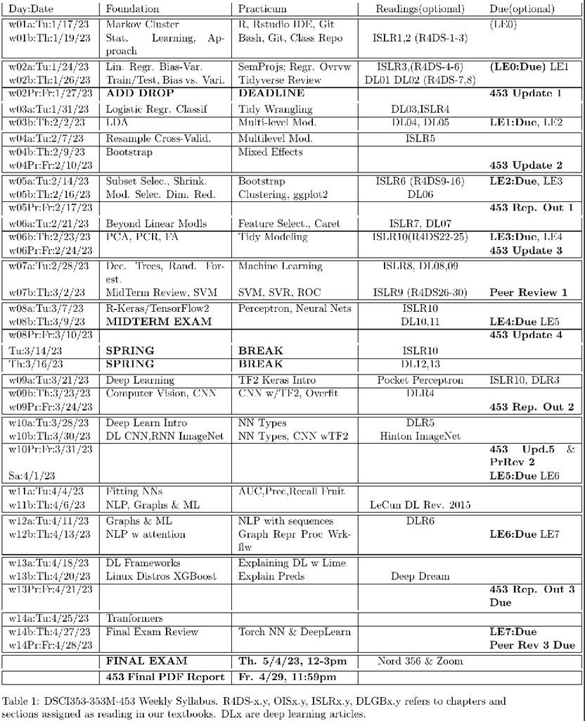

#### Current Status of Everyone in Class

- So as of today, All the elements for the course should be working for you

If not, reach out to the TAs ( @kristen hernandez and @will oltjen )

- Defining where you issue is
- And we’ll fix it

You should all have the following Elements setup

- You have Forked the `23s-dsci353-453-prof` Bitbucket Repo - And changed the `prof` to your caseID - You can sync new changes in prof repo to your personal repo.
- And you have
  - Logged into http://ondemand.case.edu
  - And launched a “RStudio Server (rxf131)”
  - And made a Git folder in your /mnt/pan/courses/dsci353-453/caseID folder
  - And do the config commands for your name and email of your Git Server
  - And made the /mnt/pan/courses/dsci353-453/caseID folder
- You have joined the DSCI Slack
  - using your caseID email address
  - And joined the DSCI353-353m-453 Slack Channel
  - And for DSCI453 students, have joined the DSCI453 SemProj Channel

Lets check your “primary group” in HPC-Markov

- Launch the SDLE Diagnostics App

Confirm your /mnt/pan/courses/caseID folder

- Is only accessible to yourself
- If others can enter your /mnt/pan/courses/dsci353-453/caseID folder
  - Then in an LXDE desktop
  - Open the file manager
  - navigate to /mnt/pan/courses/dsci353-453/caseID folder
  - right click on your folder
  - go to permissions tab
  - and change all 3 access choices to be `only owner`

##### Prof. Laura Bruckman will present in class Today

- To give more information on the Semester Projects for DSCI453 students
  - This includes 3 Reports Outs by 453 Students
  - That **all students will view and do peer grading of**

#### The Lab Exercises (LEs)

- Each LE is worth 9 points (except LE0 = 0 points)

So 63 points are in the Lab Exercises

- So these are important and critical to learning
- You will need to start on the early
  - This is why you are given two weeks to do them
- You turn in both the .Rmd and the .pdf file
  - We grade on the .pdf file in Canvas
- We expect good code styling
  - That matches the Google/Rstudio R Style Guide
  - Since this aides collaboration

The Deep learning, TensorFlow, GPU problems

- Are after the midterm break
- And these problems can be quite challenging
- So start on the LEs early
  - And ask questions in the DSCI Slack Channel

LE1 is posted today.

#### Literate Programing: Donald Knuth

- [Donald Knuth](https://en.wikipedia.org/wiki/Donald_Knuth)
  - Bachelors and Masters degrees from CWRU
  - PhD from CalTech
  - CS Professor at Stanford

Did a great many things in Computer Science

- [TAOCP: The Art of Computer Programming](https://en.wikipedia.org/wiki/The_Art_of_Computer_Programming)
  - Started in 1962, and not yet finished
  - Currently 7 volumes
- [He also develeded TeX, the precursor to LaTeX](https://en.wikipedia.org/wiki/TeX)

##### [Literature Programming](https://en.wikipedia.org/wiki/Literate_programming), was another of his goals

- Literate programming is a programming paradigm introduced by Donald Knuth
  - in which a program is given as an explanation of the program logic
    - in a natural language, such as English,
  - interspersed with snippets of macros and traditional source code,
    - from which a compilable source code can be generated.

The literate programming paradigm, as conceived by Knuth,

- represents a move away from writing programs
  - in the manner and order imposed by the computer,
  - and instead enables programmers to develop programs in the order
  - demanded by the logic and flow of their thoughts.
- Literate programs are written as an uninterrupted exposition of logic
  - in an ordinary human language, much like the text of an essay,
  - in which macros are included to hide abstractions and traditional source code.
- Literate programming (LP) tools are used
  - to obtain two representations from a literate source file:
  - one suitable for further compilation or execution by a computer, the “tangled” code,
  - and another for viewing as formatted documentation, which is said to be “woven” from the literate source.
- While the first generation of literate programming tools
  - were computer language-specific,
  - the later ones are language-agnostic
  - and exist above the programming languages.

Now a days one can integrate R and Python code in a common shared environment,

- as can be done with Rstudio v1.2 and the reticulate package.
- We use this in our data analytics in the SDLE Research Center at CWRU.

#### Agile Software Development

- In early 2000’s the way software is developed changed Radically
  - With the [Agile Manifesto](http://agilemanifesto.org/)
  - And the [Agile Software Development Principles](https://en.wikipedia.org/wiki/Agile_software_development#Agile_software_development_principles)
  - [Overview of Agile Software Development](https://en.wikipedia.org/wiki/Agile_software_development#Overview)
  - [Agile Development Philosophy](https://en.wikipedia.org/wiki/Agile_software_development#Philosophy)

Agile is enabled by Literate Programming

- And Relies on an Open Tool Chain

#### Your Open Data Science Tool Chain

##### Its all about a Data Science Tool Chain

- Use R and build on the communities foundation
- Use Rstudio as a comfy environment
- Share your Open Data and Open Source Code
- Produce Reproducible Science with Rmarkdown
  - Use [Creative Commons Licenses](https://creativecommons.org/)
  - Or other [Open Source Licenses](https://en.wikipedia.org/wiki/Comparison_of_free_and_open-source_software_licenses)
  - Such as the [Gnu Public License: GPL](https://en.wikipedia.org/wiki/GNU_General_Public_License)

###### Pilot your DSCI studies using available data

- Find available data sets
- Before starting the costly process of making data

###### Use Git repositories

- For version control
- For Collaboration
- For Open Science sharing

##### Twitter used for Data Science

- As part of setting up our Data Science Tool Chain
  - Sign up for a Twitter account
  - [Using Twitter in university research](http://blogs.lse.ac.uk/impactofsocialsciences/files/2011/11/Published-Twitter_Guide_Sept_2011.pdf)
  - [10 Commandments of Twitter for Academics](http://chronicle.com/article/10-Commandments-of-Twitter-for/131813/)

Data Science People to follow on Twitter

- @hadleywickham
- @jtleek Jeff Leek JHU
- @rdpeng Roger Peng JHU
- @daniela_witten Daniela Witten one of the ISLR authors
- @simplystats
- @Rbloggers
- @JennyBryan
- @hspter Hilary Parker
- @NSSDeviations
- @rstudio
- @rstudiotips
- @R_Programming
- @CRANberriesFeed
- @kaggle
- @SciPyTip
- @PyData
- @debian
- @ubuntu
- @GuardianData
- @UpshotNYT
- @EdwardTufte
- @ProjectJupyter
- @doctorow Cory Doctorow
- @gvanrossum founder of Python
- @NateSilver538
- @cutting founder of Hadoop
- @RProgLangRR
- @BitbucketStatus
- @CWRUITS_STATUS
- @cshirky Clay Shirky

##### Sign up for a Stack Exchange Account

- Stack Exchange, Stack Overflow
  - are a Q&A community focused on many topics.

Stack Overflow allows you to search by tag

- r and rmarkdown are useful tags for SO

###### [Stack Exchange’s Tour of Stack Overflow](http://stackoverflow.com/tour)

###### Specific Stack Exchange websites

- for [SX Data Science](https://datascience.stackexchange.com/)
- for [SX Statistics on Cross Validated](http://stats.stackexchange.com/)
- for [SX Open Data](http://opendata.stackexchange.com/)

##### Efficiently browse you SX sites

- Google (but more random)
- [The Stack Exchange apps](http://stackapps.com/)
- Using an [RSS Feed reader such as Feedly](http://feedly.com/i/latest) is a good way

##### Online Git Server Communities

- After your [BitBucket Account](http://bitbucket.org)
- You’ll probably want a [GitHub](http://github.com/) account,.
- Many R Projects are there, and
- you can fork their repo’s to inspect the code very easily.

##### Slack, another component of [Agile Sofware Development]

- [cwru-dsci.slack.com](https://cwru-dsci.slack.com/)
  - an online collaboration tool
- Its an intrinsic part of agile software development
  - There is slack app for phones
  - And client for computers, its on VDI.

#### You Online Data Science Portfolio

- Doing open, reproducible data science
- Lets you share a portfolio of codes and projects
- Cite it in your resume
- Build a community of supporters and collaborators
- Need to be conscious of data use terms and agreements
  - Funded research at CWRU falls under IP agreements
  - So when you consider licenses you want to use
  - They must be consistent with the IP terms that came
  - With datasets and codes

##### An Example, Emeline Liu

- [emelineliu.com](http://emelineliu.com/)
  - This website, which runs off of [Github Pages](https://pages.github.com/) and [Jekyll](https://jekyllrb.com/), is my latest project.
  - Right now, I’m using [Poole](http://getpoole.com/) as a foundation for my website/blog.

#### Links

- http://www.r-project.org
- Rory Winston, for the [Learning R Intro](http://www.theresearchkitchen.com/archives/1017)
- StackExchange http://stackexchange.com/sites
- Twitter http://twitter.com
- Slack http://slack.com
- [emelineliu.com](http://emelineliu.com/)